# polymapR example with SWxBE mapping population

Jeekin Lau

Linkage mapping done with R package ‘polymapR’ then imported into R package ‘mappoly’ for conversion into genotypic probabilities then QTL mapping done in ‘QTLpoly’

This will be an example for mapping the “Stormy Weather” x “Brite Eyes” mapping population showing all the steps used from raw data dosage calls from fitPoly all the way to conducting QTL analysis using QTLpoly.

# Loading necessary packages

As a first step, we need to load all the required packages and make sure your working directory is set to where all your input files will be. Load the following packages:

```r
library(mappoly)
library(qtlpoly)
library(polymapR)
library(doParallel)
```

# Loading in dosage calls

Dosage calls obtained from ‘fitpoly’ are needed in order to conduct linkage mapping in ‘polymapR’ and must be in a matrix consisting of markers in rows and individuals as columns. The first two columns will be named P1 and P2.

Load in the included dosage calls file and look at the first 10 markers and the first 4 individuals with the two parental calls:

```r
ALL_dosages<-as.matrix(read.csv("16009_16401_recalled_NAremoved.csv",
                          stringsAsFactors = FALSE,
                          row.names = 1)) #first column contains rownames

ALL_dosages[1:10,1:6]
```

```
##               P1 P2 X16009_N001 X16009_N005 X16009_N006 X16009_N009
## Affx-86775184  1  0           0           0           1           1
## Affx-86775194  0  3           1           1           1           2
## Affx-86775195  0  1          NA           0           0           0
## Affx-86775198  1  0           0           0           0           1
## Affx-86775199  4  4          NA          NA          NA           4
## Affx-86775201  3  2           1           1           1          NA
## Affx-86775204  4  4           4           4           4           4
## Affx-86775205  4  2           2           3           2           2
## Affx-86775208  4  2           4           3           3           3
## Affx-86775214  0  0           0           0           0           0
```

# Segregation distortion tests

checkF1 funtion does a number of segregation tests and produces an list with a dataframe: F1checked$checked_F1

```r
F1checked <- checkF1(dosage_matrix = ALL_dosages,parent1 = "P1",parent2 = "P2",
                     F1 = colnames(ALL_dosages)[3:ncol(ALL_dosages)],
                     polysomic = TRUE, disomic = FALSE, mixed = FALSE, ploidy = 4)


F1checked_remove_qall<-subset(F1checked$checked_F1, qall_mult > 0)
F1checked_remove_p0.001<-subset(F1checked_remove_qall, Pvalue_bestParentfit >= 0.001)
ALL_dosages_filteredqall<-subset(ALL_dosages, row.names(ALL_dosages) %in% F1checked_remove_qall$MarkerName)
ALL_dosages_filteredqall_n_p0001<-subset(ALL_dosages_filteredqall, row.names(ALL_dosages_filteredqall) %in% F1checked_remove_p0.001$MarkerName)
ALL_dosages<-ALL_dosages_filteredqall
#ALL_dosages<-ALL_dosages_filteredqall_n_p0001
```

# Summary Data

```r
mds <- marker_data_summary(dosage_matrix = ALL_dosages,
                           ploidy = 4,
                           pairing = "random",
                           parent1 = "P1",
                           parent2 = "P2",
                           progeny_incompat_cutoff = 0.05)
```

```
## Calculating parental info...
## Checking compatability between parental and offspring scores...
##
## #### parental_info
##
## |     | P2_0| P2_1| P2_2| P2_3| P2_4|
## |:----|----:|----:|----:|----:|----:|
## |P1_0 | 1795| 2198|  691|  190|   30|
## |P1_1 | 2814| 2503| 1129|  471|  194|
## |P1_2 |  661| 1366| 1224| 1205|  639|
## |P1_3 |  195|  457| 1055| 2334| 2583|
## |P1_4 |   30|  195|  631| 2041| 1560|
##
## #### offspring_incompatible
##
## |     |  P2_0| P2_1| P2_2| P2_3|  P2_4|
## |:----|-----:|----:|----:|----:|-----:|
## |P1_0 |  0.10| 0.43| 0.17| 4.28| 26.01|
## |P1_1 |  0.32| 0.35| 0.10| 0.91|  2.48|
## |P1_2 |  0.10| 0.10| 0.00| 0.13|  0.10|
## |P1_3 |  2.76| 0.70| 0.08| 0.33|  0.31|
## |P1_4 | 22.10| 3.69| 0.19| 0.50|  0.10|
##
## #### Incompatible individuals:
##
## None
```

# Converting markers to most basic form and removing markers based off of marker quality

## Converting markers

First we can look at the types of markers we have in our dataset

```r
pq_before_convert <- parental_quantities(dosage_matrix = ALL_dosages,
                                         las = 2)
```

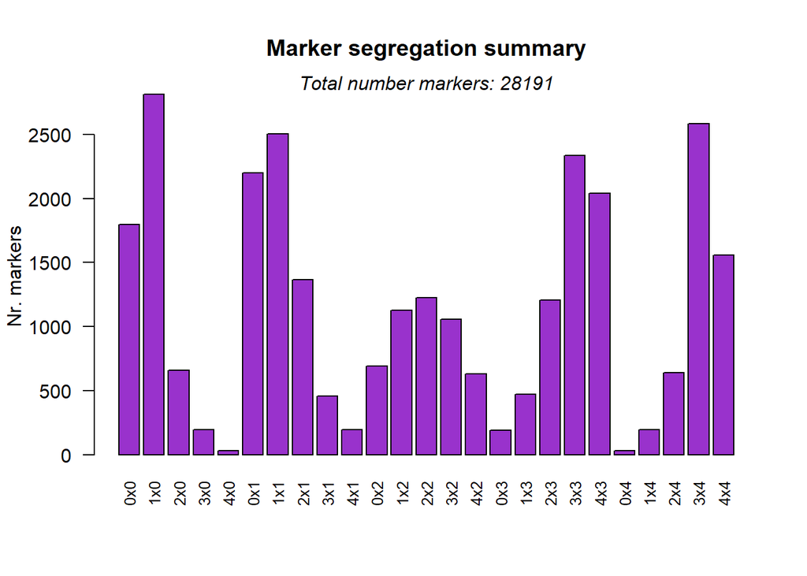

```
## |          |  0x0|  1x0| 2x0| 3x0| 4x0|  0x1|  1x1|  2x1| 3x1| 4x1| 0x2|  1x2|  2x2|  3x2| 4x2| 0x3| 1x3|  2x3|  3x3|  4x3| 0x4| 1x4| 2x4|  3x4|  4x4|
## |:---------|----:|----:|---:|---:|---:|----:|----:|----:|---:|---:|---:|----:|----:|----:|---:|---:|---:|----:|----:|----:|---:|---:|---:|----:|----:|
## |frequency | 1795| 2814| 661| 195|  30| 2198| 2503| 1366| 457| 195| 691| 1129| 1224| 1055| 631| 190| 471| 1205| 2334| 2041|  30| 194| 639| 2583| 1560|
```

Then we convert all our data to most simple marker forms. For example the segregtion of 1x0 markers is the same as 3x4 markers. 1x0 markers are AAAB x AAAA and 3x4 markers are ABBB x BBBB which are essentially both just 1x0 or simplex x nulliplex markers.

```r
segregating_data <- convert_marker_dosages(dosage_matrix = ALL_dosages, ploidy = 4)
```

```
##
## #### Marker dosage frequencies:
##
## |     | P2_0| P2_1| P2_2| P2_3|
## |:----|----:|----:|----:|----:|
## |P1_0 |    0| 4624| 1322|    0|
## |P1_1 | 5786| 4837| 2184|  928|
## |P1_2 | 1300| 2571| 1224|    0|
##
## markers not converted: 14852
##
## markers 1 parent converted: 834
##
## markers 2 parents converted: 12505
##
## non-segregating markers deleted: 3415
```

Now, lets take another view of our markers after converting the markers over to simplest form.

```r
pq_after_convert <- parental_quantities(dosage_matrix = segregating_data)
```

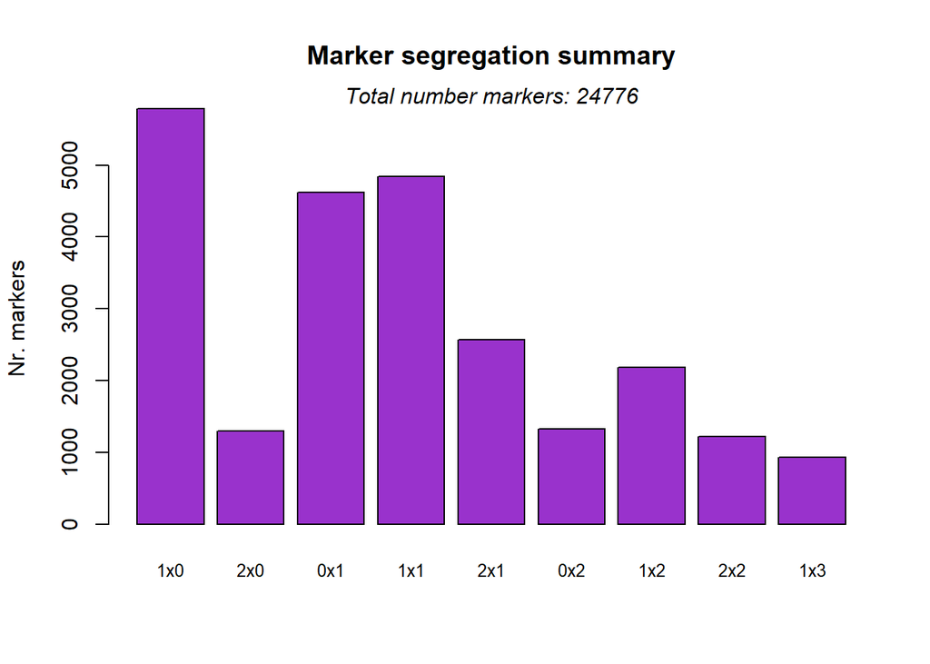

```
## |          |  1x0|  2x0|  0x1|  1x1|  2x1|  0x2|  1x2|  2x2| 1x3|
## |:---------|----:|----:|----:|----:|----:|----:|----:|----:|---:|
## |frequency | 5786| 1300| 4624| 4837| 2571| 1322| 2184| 1224| 928|
```

## Eliminating markers based off missing data per marker

Missing value rate per marker (start out using cuttof of 0.10 but if there are problems in mapping try rerunning this step with 0.05)

```r
screened_data <- screen_for_NA_values(dosage_matrix = segregating_data,
                                      margin = 1, # margin 1 means markers
                                      cutoff =  0.0075,
                                      print.removed = FALSE)
```

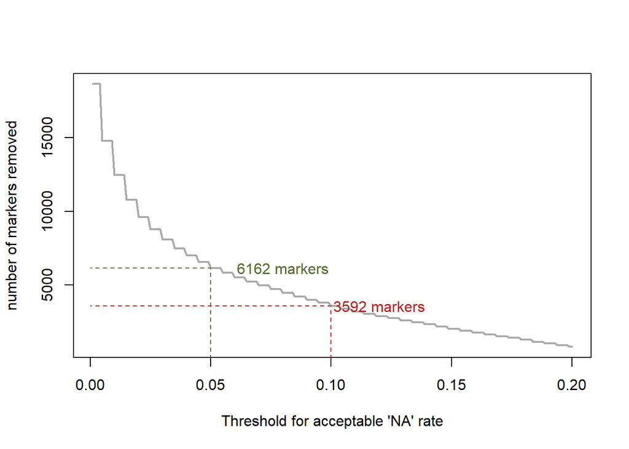

```
##
## Number of removed markers :  14779
##
##
## There are now 9997 markers leftover in the dataset.
```

## Eliminating markers based off missing data per individual

Missing value rate per individual seeing if there is too much missing data in individuals Again, it is not clear what an acceptable threshold for the rate of missing values should be, but we recommend a cut-off rate of 0.1 - 0.15 (10-15%) missing values allowed.

```r
screened_data2 <- screen_for_NA_values(dosage_matrix = screened_data,
                                       cutoff = 0.075,
                                       margin = 2, #margin = 2 means columns
                                       print.removed = FALSE)
```

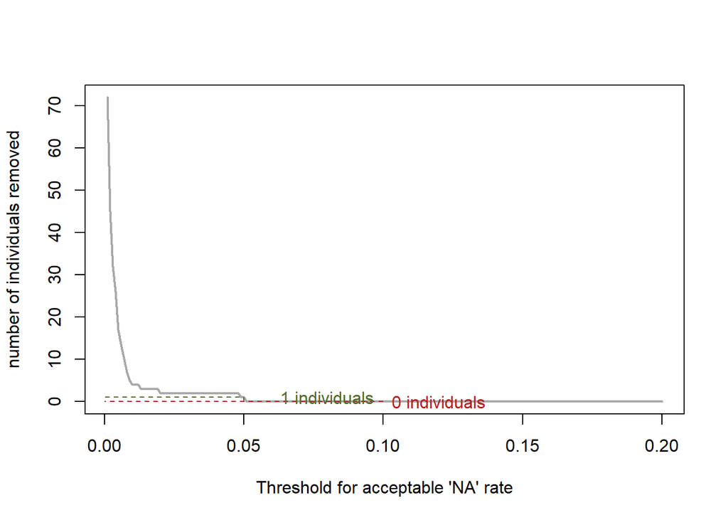

```
## [1] "Nothing removed at this rate."
```

## Eliminating duplicate individuals

Screen for duplicate individuals and the cutoff is set at 0.95 similarity it will merge the individuals that look too similar that they are probably clones (probably a result of mislabeling the vials or propagation error)

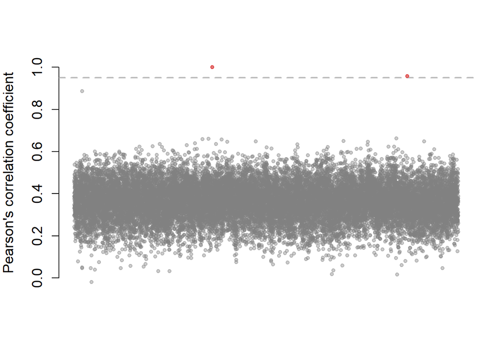

```
##
## Combining X16009_N089 & X16009_N189 into X16009_N089
##
## Combining X16401_N104 & X16401_N105 into X16401_N104
##
## ####  2 individuals removed:
##
##      _             _
## [1,] "X16009_N189" "X16401_N105"
## |_           |_           |
## |:-----------|:-----------|
## |X16009_N189 |X16401_N105 |
```

```r
screened_data3 <- screen_for_duplicate_individuals(dosage_matrix = screened_data2,
                                                   cutoff = 0.95,
                                                   plot_cor = T)
```

## Screen for duplicate markers and binning

Markers segregating like other markers are binned and one representative marker is chosen to represent all the markers.

```r
screened_data4 <- screen_for_duplicate_markers(dosage_matrix = screened_data3)
```

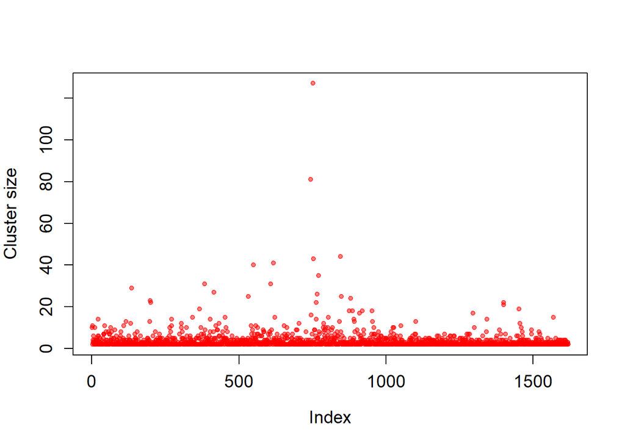

```r
dim(screened_data4$filtered_dosage_matrix)

filtered_data <- screened_data4$filtered_dosage_matrix
```

Look at the summary function for the filtered data just so you have clear record of number of markers right before begining to do linkage mapping

```r
pq_screened_data <- parental_quantities(dosage_matrix = filtered_data)
```

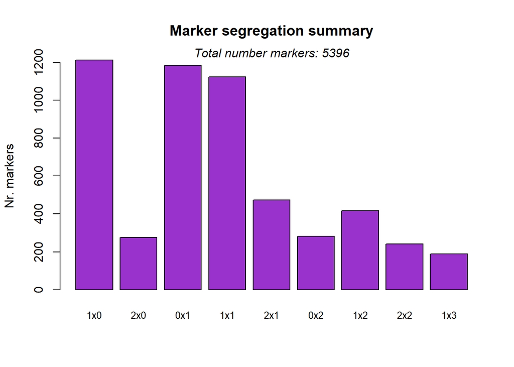

```
## |          |  1x0| 2x0|  0x1|  1x1| 2x1| 0x2| 1x2| 2x2| 1x3|
## |:---------|----:|---:|----:|----:|---:|---:|---:|---:|---:|
## |frequency | 1212| 276| 1184| 1123| 474| 281| 417| 241| 188|
```

# Clustering Markers

Use simplex x nulliplex (AAAB x AAAA)markers to define chromosomes and homologues can add a ‘ncore’ statement (can use multiple cores to help run the analysis faster)

```r
SN_SN_P1 <- linkage(dosage_matrix = filtered_data,
                    markertype1 = c(1,0),
                    target_parent = "P1",
                    other_parent = "P2",
                    ploidy = 4,
                    pairing = "random",
                    ncores = 4)
```

```
## Number of combinations per iteration: 43169
## Reserving approximately 505MB RAM per iteration
```

```
## In total 733866 combinations, which will run in 17 iteration(s)...
```

```
##
## Total markercombinations: 733866 at LOD cutoff of 0
```

```
##
## For 733866 marker combinations r, LOD and phase were written to output.
##
## Run on a Windows machine using 4 cores, taking 0.36 minutes.
```

Use these following lines to figure out at what lod is the chromosome level and what is the homologue level

```
## Total number of edges: 91271
```

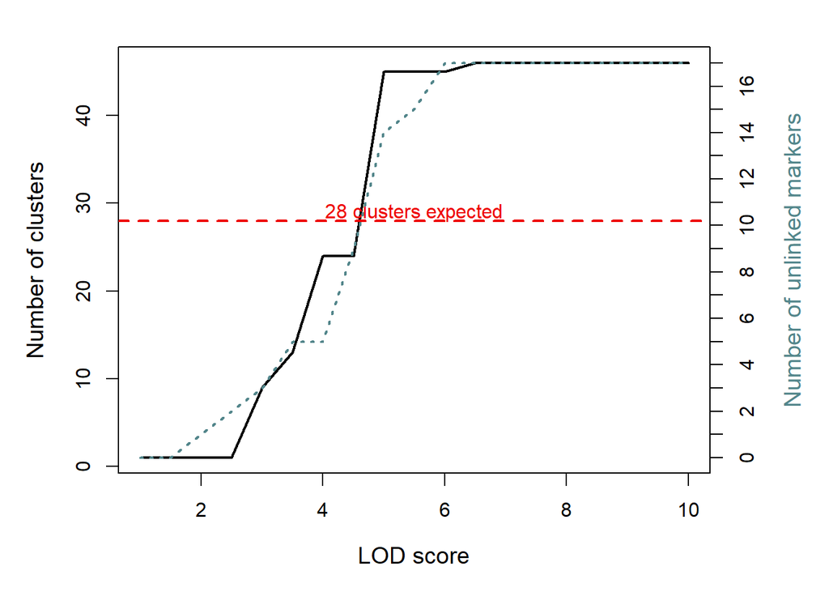

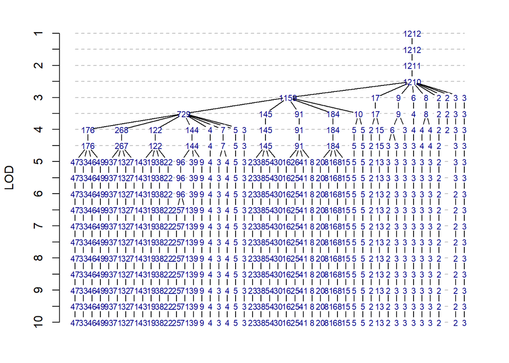

```r
P1_homologues <- cluster_SN_markers(linkage_df = SN_SN_P1,
                                    LOD_sequence = seq(1, 10, .5),
                                    LG_number = 7,
                                    ploidy = 4,
                                    parentname = "P1",
                                    plot_network = FALSE,
                                    plot_clust_size = T)
```

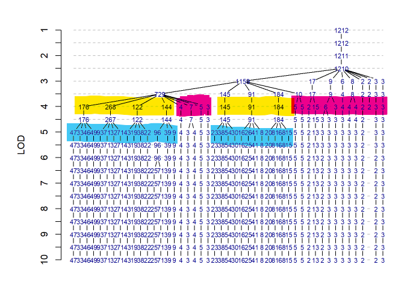

Looking at the picture the 7 linkage groups are highlighted at LOD 4. The homologues are highlighted in blue. The markers highlighted in pink are the ones we are removing.

## Remove markers non-clustering markers

Next few lines does a few things. Fist we are isolating all the 1x0 markers at LOD 4 and isolating them in an object called P1_hom_LOD4 (arbitrary name). Then we remove the names of marker clusters at LOD 4 that we can see from the picture above clearly do not belong. 5, 6, 7, 8, 12, 13, 14, 15, 16, 17, 18, 19, 20, 21, 22, 23, 24. We also remove the duplicate markers from the analysis.

```r
P1_hom_LOD4 <- P1_homologues[["4"]]
t <- table(P1_hom_LOD4$cluster)
print(paste("Number of clusters:",length(t)))
t[order(as.numeric(names(t)))]

remove<-subset(P1_hom_LOD4, cluster=="5" | cluster=="6" | cluster=="7" |cluster=="8" |cluster=="12" | cluster=="13" | cluster=="14" |cluster=="15" | cluster=="16" |cluster=="17" | cluster=="18" |cluster=="19" | cluster=="20" | cluster=="21" |cluster=="22" | cluster=="23"| cluster=="24")#round1

removematrix<-as.matrix(remove)
subset_binned<-screened_data4$bin_list[removematrix[1:nrow(removematrix),1]]
removed_duplicates<-unlist(subset_binned)
markers_to_remove<-c(removematrix[1:nrow(removematrix),1],removed_duplicates)
```

This shows the number of markers prior to removal of 1x0 markers that do not fit well when looking at the clustering.

```r
dim(ALL_dosages)
```

```
## [1] 28191   204
```

This step removes the markers we have isolated that do not belong

```r
ALL_dosages_removed<-subset(ALL_dosages, !(row.names(ALL_dosages) %in% markers_to_remove))
ALL_dosages<-ALL_dosages_removed
```

Resulting number of markers:

```r
dim(ALL_dosages)
```

```
## [1] 28101   204
```

## Rerun from beginning by removing the problematic markers

```r
#summary data
mds <- marker_data_summary(dosage_matrix = ALL_dosages,
                           ploidy = 4,
                           pairing = "random",
                           parent1 = "P1",
                           parent2 = "P2",
                           progeny_incompat_cutoff = 0.05)

#Convert marker dosages to simple segregations; remove non-segregating data
pq_before_convert <- parental_quantities(dosage_matrix = ALL_dosages,
                                         las = 2)
```

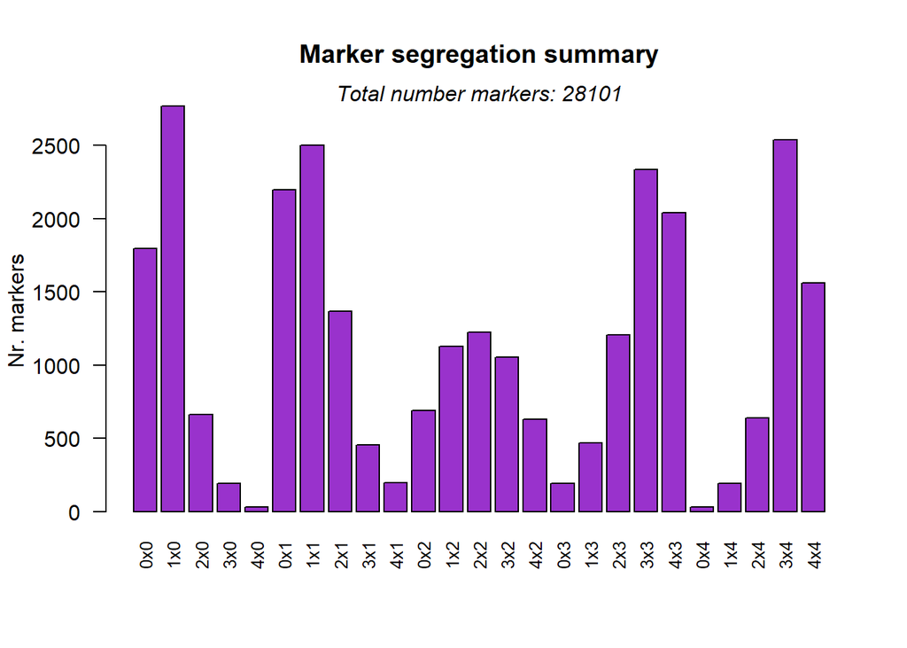

```r
segregating_data <- convert_marker_dosages(dosage_matrix = ALL_dosages, ploidy = 4)

pq_after_convert <- parental_quantities(dosage_matrix = segregating_data)
```

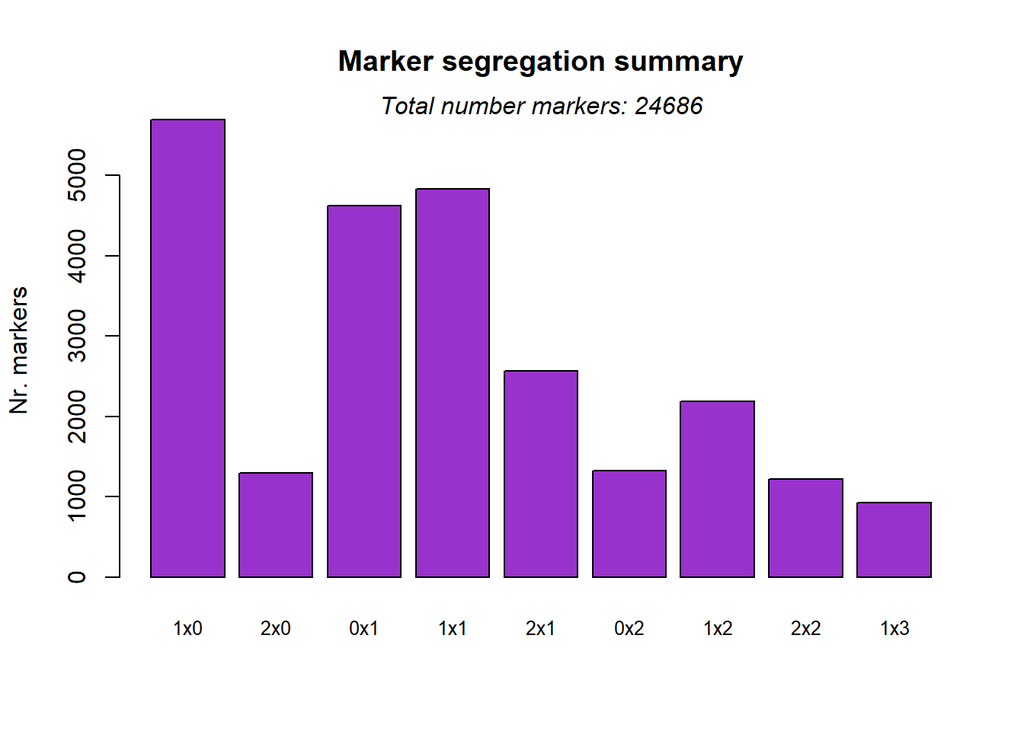

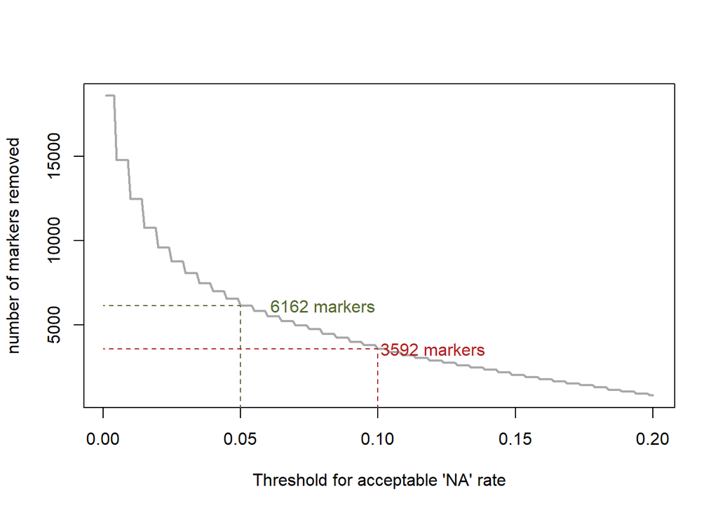

```r
#missing value rate per marker (start out using cuttof of 0.10 but if there are problems in mapping try rerunning this step with 0.05)
screened_data <- screen_for_NA_values(dosage_matrix = segregating_data,
                                      margin = 1, # margin 1 means markers
                                      cutoff =  0.0075,
                                      print.removed = FALSE)
```

```r
#mising value rate per individual seeing if there is too much missing data in individuals
# Again, it is not clear what an acceptable threshold for the rate of missing values should be, but we recommend a cut-off rate of 0.1 - 0.15 (10-15%) missing values allowed.
screened_data2 <- screen_for_NA_values(dosage_matrix = screened_data,
                                       cutoff = 0.075,
                                       margin = 2, #margin = 2 means columns
                                       print.removed = FALSE)
```

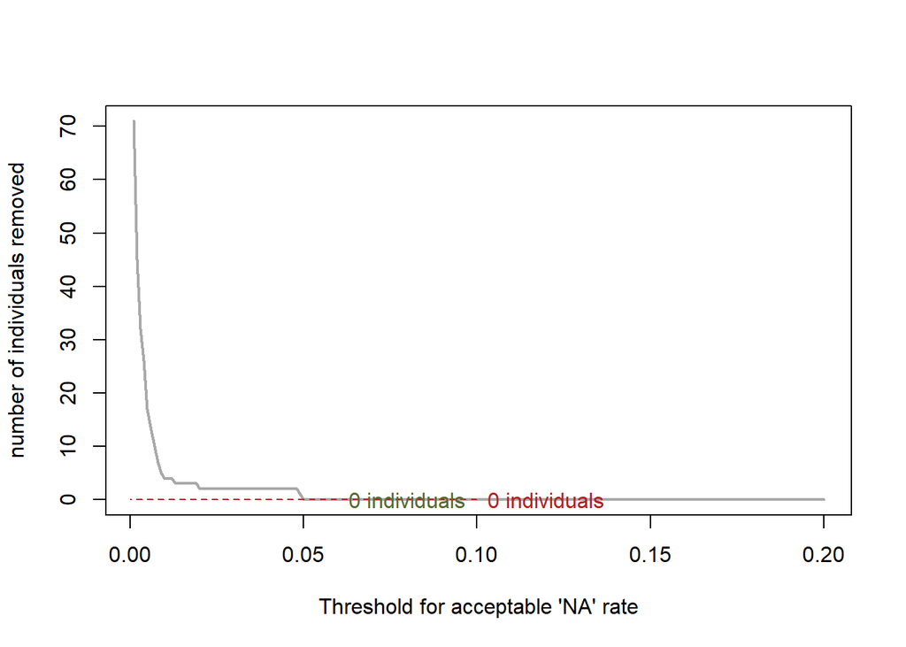

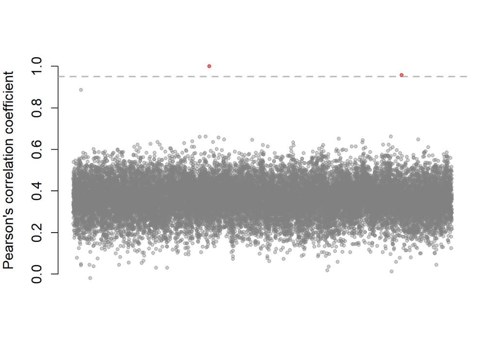

```r
#screen for duplicate individuals
screened_data3 <- screen_for_duplicate_individuals(dosage_matrix = screened_data2,
                                                   cutoff = 0.95,
                                                   plot_cor = T)
```

```r
#screen for duplicate markers
screened_data4 <- screen_for_duplicate_markers(dosage_matrix = screened_data3)
```

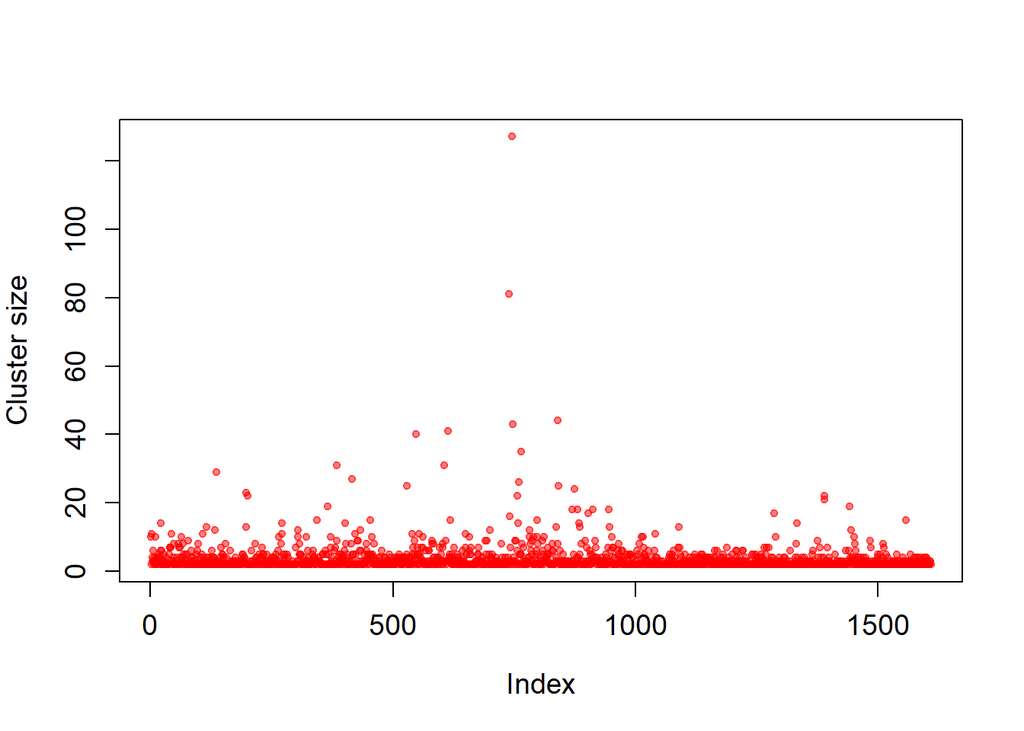

```r
dim(screened_data4$filtered_dosage_matrix)

filtered_data <- screened_data4$filtered_dosage_matrix


#look at the summary function for the filtered data just so you have clear record of number of marker
pq_screened_data <- parental_quantities(dosage_matrix = filtered_data)
```

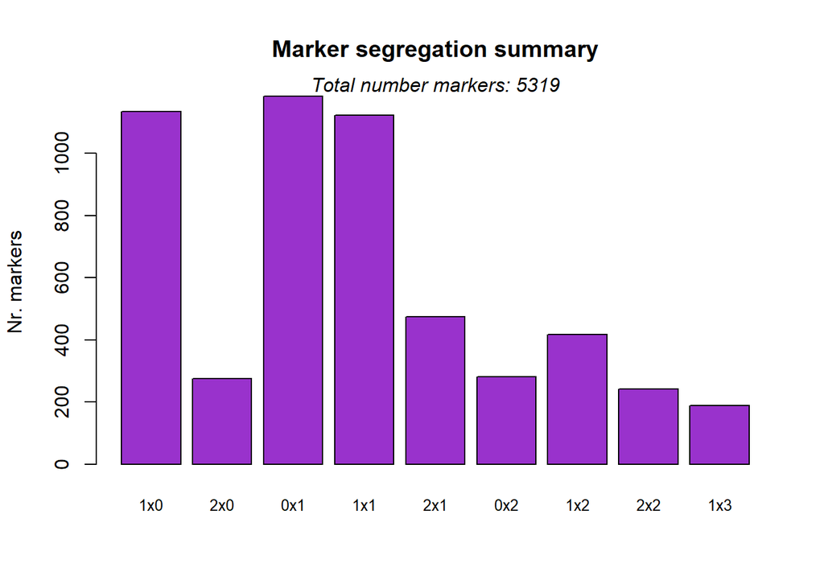

```r
#use simplex x nulliplex (AAAB x AAAA)markers to define chromosomes and homologues
#can add a ncore statement

SN_SN_P1 <- linkage(dosage_matrix = filtered_data,
                    markertype1 = c(1,0),
                    target_parent = "P1",
                    other_parent = "P2",
                    ploidy = 4,
                    pairing = "random",
                    ncores = 4)
```

## New P1 clustering of 1x0 markers

```
## Total number of edges: 87148
```

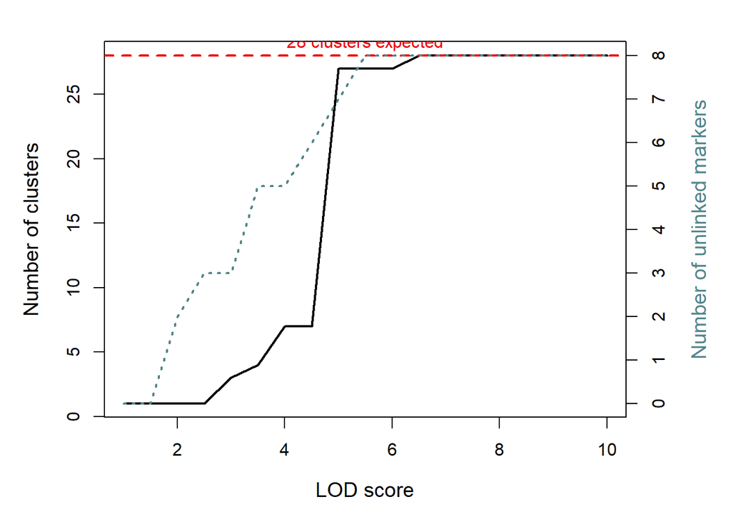

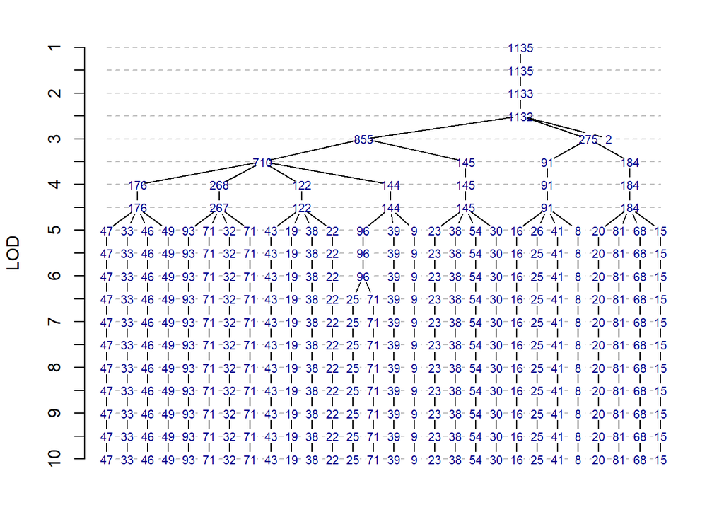

```r
P1_homologues <- cluster_SN_markers(linkage_df = SN_SN_P1,
                                    LOD_sequence = seq(1, 10, .5),
                                    LG_number = 7,
                                    ploidy = 4,
                                    parentname = "P1",
                                    plot_network = FALSE,
                                    plot_clust_size = T)
```

# Defining the linkage groups

```r
P1_hom_LOD4 <- P1_homologues[["4"]]
t <- table(P1_hom_LOD4$cluster)
print(paste("Number of clusters:",length(t)))
```

```
## [1] "Number of clusters: 7"
```

```r
t[order(as.numeric(names(t)))]
```

```
##
##   1   2   3   4   5   6   7
## 176 268 122 144 145  91 184
```

```r
P1_hom_LOD5 <- P1_homologues[["6.5"]]
t <- table(P1_hom_LOD5$cluster)
print(paste("Number of clusters:",length(t)))
```

```
## [1] "Number of clusters: 28"
```

```r
t[order(as.numeric(names(t)))]
```

```
##
##  1  2  3  4  5  6  7  8  9 10 11 12 13 14 15 16 17 18 19 20 21 22 23 24 25 26
## 47 33 46 49 93 71 32 71 43 19 38 22 25 71 39  9 23 38 54 30 16 25 41  8 20 81
## 27 28
## 68 15
```

```r
#defines the linkage groups
LGHomDf_P1 <- define_LG_structure(cluster_list = P1_homologues,
                                  LOD_chm = 4,
                                  LOD_hom = 6.5,
                                  LG_number = 7)
```

```
##
## #### SxN Marker(s) lost in clustering step at LOD 6.5:
##
## |_             |_             |_             |
## |:-------------|:-------------|:-------------|
## |Affx-86813717 |Affx-86831830 |Affx-86777771 |
```